# ISyE 3770 HW9

Devin Fromond

2024-11-24

## Problem 9.1.10

### Part A

We begin by calculating the Standard Error of the mean:
$$SE=\frac{\sigma}{\sqrt{n}}=\frac{0.25}{\sqrt{8}}=0.08839$$

We fine the Z-Scores to be:
$$Z_1=\frac{4.85-5}{SE}=-1.697$$
$$Z_2=\frac{5.15-5}{SE}=1.697$$

Therefore, we find $\alpha$ to be:
$$\alpha=2(P(Z<-1.697))=2(0.0449)=0.0898$$

Finally, we arrive at our answer of $\alpha = 0.0898$.

### Part B

We will use R to calculate the new Z-Scores.

```r
SE = 0.08839
z1_prime <- (4.85 - 5.1) / SE
z2_prime <- (5.15 - 5.1) / SE
pnorm(z1_prime) + (1 - pnorm(z2_prime))
```

```
## [1] 0.2881467
```

## Problem 9-23 [NOTES]

### Part A

We calculate the Z-Score to be the following:
$$Z=\frac{5.2-5}{SD}=2.2627$$
Therefore, we find the P-Value to be:
$$P(Z \geq 2.2627)=1-P(Z \leq 2.2627)=1-0.9881=0.0119$$
$$PValue=2(0.0119)=0.0238$$
Therefore, we find the P-Value is $0.0238$.

### Part B

We use similar logic as in Part A.
$$Z=\frac{4.7-5}{SD}=-3.395$$
We find the P-Value to be calculated as:
$$P(Z \leq -3.395)=0.00034$$
$$PValue=2(0.00034)=0.00068$$

### Part C

We calculate the Z-Score to be:
$$Z=\frac{5.1-5}{SD}=1.131$$
We calculate the P-Value:
$$P(Z \geq 1.131)=1-P(Z \leq 1.131)=1-0.8710=0.1290$$
$$PValue=2(0.1290)=0.2580$$

## Problem 9.2.6

### Part A

$$PValue=2(P(Z \leq -0.946))=2(0.1720)=0.3440$$

### Part B

We will use Z to make this problem easier…

```r
# Givens
mu0 <- 3
xbar <- 2.78
sigma <- 0.9
n <- 15
alpha <- 0.05

SE <- sigma / sqrt(n)

Z <- (xbar - mu0) / SE
p_value <- 2 * pnorm(-abs(Z))

Z_alpha <- qnorm(1 - alpha/2)

# Calculate critical sample means
xbar_lower <- mu0 - Z_alpha * SE
xbar_upper <- mu0 + Z_alpha * SE

mu_alt <- 3.25

# Calculate Z lower and Z upper
Z_L <- (xbar_lower - mu_alt) / SE
Z_U <- (xbar_upper - mu_alt) / SE

# Calculate power
pnorm(Z_L) + (1 - pnorm(Z_U))
```

```
## [1] 0.1895111
```

Therefore, we observe a final answer of $0.18951$ for the test’s power.

## Problem 9.3.8

### Part A

We begin by calculating the sample statistics using R.

```r
rainfall <- c(18.0, 30.7, 19.8, 27.1, 22.3, 18.8, 31.8, 23.4, 21.2, 27.9, 31.9, 27.1, 25.0, 24.7, 26.9, 21.8, 29.2, 34.8, 26.7, 31.6)

n <- length(rainfall)

mean_rainfall <- mean(rainfall)

sd_rainfall <- sd(rainfall)

mean_rainfall
```

```
## [1] 26.035
```

```r
sd_rainfall
```

```
## [1] 4.784765
```

Now, we calculate the standard error:
$$SE=\frac{4.7847}{\sqrt{20}}=1.0694$$

Now, we calculate the test statistic:
$$t=\frac{26.035-25}{1.0694}=0.9675$$
We then calculate the critical t-value and p-value using R:

```r
t <- (26.035 - 25) / 1.0694
alpha <- 0.01
df <- n - 1
t_crit <- qt(1 - alpha, df)
t_crit
```

```
## [1] 2.539483
```

```r
p_value <- 1 - pt(t, df)
p_value
```

```
## [1] 0.1726437
```

Since $t=0.9675 < 2.539$ and $PValue=0.1726>\alpha=0.01$, we fail to reject the null hypothesis.

### Part B

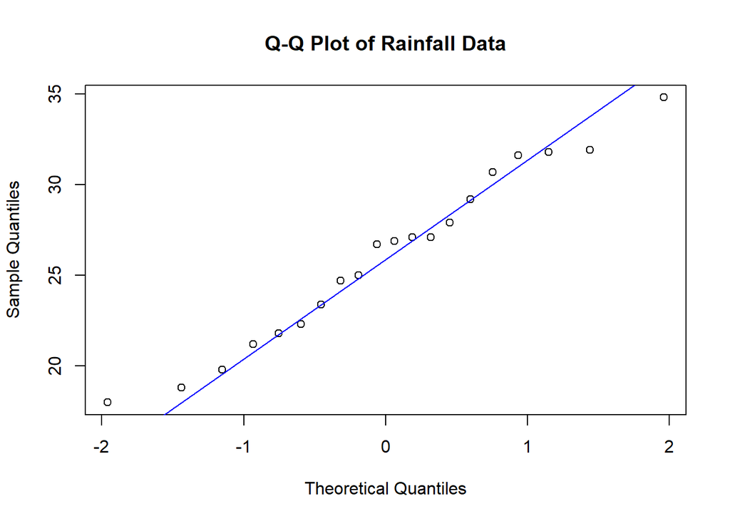

```r
rainfall <- c(18.0, 30.7, 19.8, 27.1, 22.3, 18.8, 31.8, 23.4, 21.2, 27.9, 31.9, 27.1, 25.0, 24.7, 26.9, 21.8, 29.2, 34.8, 26.7, 31.6)

qqnorm(rainfall, main = "Q-Q Plot of Rainfall Data")
qqline(rainfall, col = "blue")
```

```r
shapiro_test <- shapiro.test(rainfall)

shapiro_test
```

```
##
##  Shapiro-Wilk normality test
##
## data:  rainfall
## W = 0.97025, p-value = 0.7601
```

We observe $W=0.97025$ and $PValue=0.7601$, therefore, since the P-Value is greater than the common significance level, we fail to reject the null hypothesis.

We find the data follows a normal distribution.

### Part E

We can construct a one-tailed CI at 99% CI ($\alpha =0.01$) with $df=19$.
$$t_{0.99,19}=2.539$$
Now, we find the lower confidence bound:
$$26.035-(2.539)(1.0694)=26.035-2.719=23.316$$

Therefore, we are 99% confident the true mean rainfall is greater than or equal to 23.316 acre-feet. Since the lower confidence bound is less than the hypothesized mean, we cannot be 99% confident that the true mean exceeds 25 acre-feet.

## Problem 9.4.3

### Part A

We will use R to speed up calculations:

```r
chi_sq_stat <- (16 * 0.75^2) / (0.09^2)
p_value <- 1 - pchisq(chi_sq_stat, df = 16)
p_value
```

```
## [1] 0
```

Since we find the p-value to be approximately 0, we find this value to be less than the significance level of $\alpha =0.05$ and therefore reject the null hypothesis.

Therefore, we find there is strong significance to conclude the std dev. of performance time exceeds 0.09 seconds. Since the p-value is approximately 0, we observe it is a statistically significant result.

### Part B

We will again use R to simplify calculations:

```r
chi_sq_critical <- qchisq(0.05, df = 16, lower.tail = FALSE)
lower_limit_variance <- (16 * 0.75^2) / chi_sq_critical
lower_limit_sigma <- sqrt(lower_limit_variance)
lower_limit_sigma
```

```
## [1] 0.5850251
```

The 95% one-sided confidence interval shows the true std dev. is at least 0.585 seconds with 95% confidence. Since the standard deviation is below this lower limit, we find it is plausible the current standard deviation exceeds this value.

We find that $0.585 > 0.09$ seconds, so we find supporting evidence from the conclusion of part (a).

## Problem 9.5.4

### Part A

We begin by calculating SE from $\hat{p}=\frac{117}{484}=0.2417$.
$$SE=\sqrt{\frac{(0.5)(0.5)}{484}}=0.0227$$

We find the following:
$$z=\frac{0.2417-0.5}{0.0227}=-11.38$$

We calculate the p-value:

```r
p_value <- 2 * pnorm(-11.38)
p_value
```

```
## [1] 5.259973e-30
```

Since the P-Value is less than the significance level of $\alpha =0.05$, we reject the null hypothesis.

Therefore, we find the data from Eng. Horizons are not consistent with Fortune’s claim. We find the p-value is approximately zero which shows a statistically significant difference.

### Part B

We use R to make calculations better…

```r
n <- 484
x <- 117
p_hat <- x / n
p0 <- 0.5
SE <- sqrt(p0 * (1 - p0) / n)
z <- (p_hat - p0) / SE
p_value <- 2 * pnorm(z)

SE_p_hat <- sqrt(p_hat * (1 - p_hat) / n)
z_star <- qnorm(0.975)
lower_limit <- p_hat - z_star * SE_p_hat
upper_limit <- p_hat + z_star * SE_p_hat
confidence_interval <- c(lower_limit, upper_limit)
confidence_interval
```

```
## [1] 0.2035933 0.2798778
```

The Fortune’s claim is $p=0.5$. Since this value is not within the 95% CI calculated above, we find that engineers furthering their education is significantly different than 50%.

Therefore, we conclude that the data are inconsistent with the claim.